# Zijn mensen die uit een succesvol gezin komen meer wiskundig geletterd dan mensen die uit minder succesvolle gezinnen komen?

Analyse resultaten

Pieter Van Keer, Vic Rottiers, Brent De Craemer, Nicolas De Wree

# GradeMath4IT - EducationFather

Op onderstaande grafiek is te zien hoe kinderen scoren op Math4IT opgedeeld per educatie niveau van de vader

```
## No summary function supplied, defaulting to `mean_se()`
```

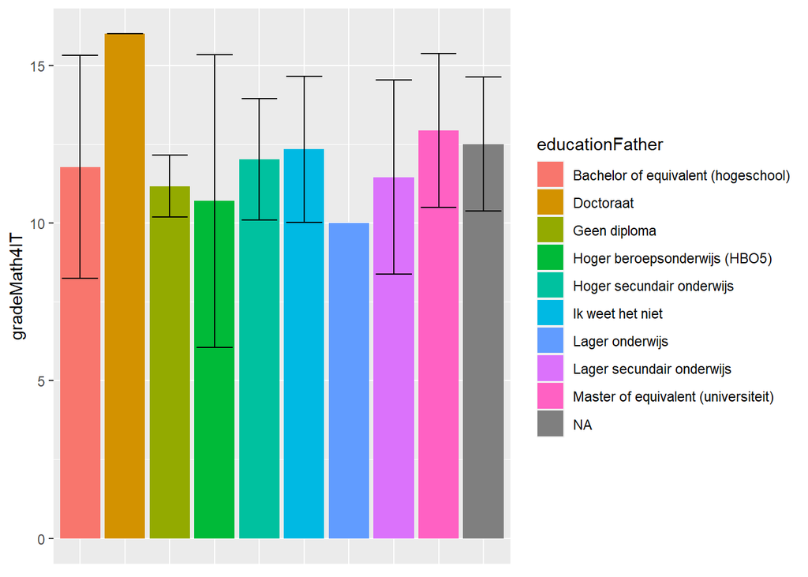

```r
educationFather <- dataset$EducationFather
gradeMath4IT <- dataset$GradeMath4IT

ggplot(data = dataset, mapping = aes(x = educationFather, y = gradeMath4IT,fill = educationFather)) +
  geom_bar(stat = "summary", fun.y = "mean", )  +
  geom_errorbar(stat = "summary", fun.data = "mean_sdl", fun.args = list(mult=1),width = .8) +
    theme(axis.title.x=element_blank(),
        axis.text.x=element_blank(),
        axis.ticks.x=element_blank())
```

## Onderzoek

```r
s1 <- dataset$GradeMath4IT[dataset$EducationFather == "Master of equivalent (universiteit)"]
s2 <- dataset$GradeMath4IT[dataset$EducationFather == "Lager secundair onderwijs"]

(t <- t.test(s1,s2))
```

```
##
##  Welch Two Sample t-test
##
## data:  s1 and s2
## t = 1.9536, df = 34.878, p-value = 0.05881
## alternative hypothesis: true difference in means is not equal to 0
## 95 percent confidence interval:
##  -0.05798898  3.00936319
## sample estimates:
## mean of x mean of y
##  12.93023  11.45455
```

```r
# Pooled standard deviation for two samples x and y
pooled_sd <- function(x, y) {
  sd_x <- sd(x, na.rm = TRUE)
  sd_y <- sd(y, na.rm = TRUE)
  n_x <- length(x)
  n_y <- length(y)

  sqrt( ((n_x - 1) * sd_x^2 + (n_y - 1) * sd_y^2)
        / (n_x + n_y - 2))
}

# Effect size, Cohen's d
cohens_d <- function(x, y) {
  (mean(y, na.rm = TRUE) - mean(x, na.rm = TRUE)) / pooled_sd(x, y)
}



cohend <- cohens_d(s1,s2)
```

## Conclusie

De p-waarde is: 0.059  
De cohens-d is: -0.549

Hieruit kunnen we concluderen dat de opleiding van de vader een middelmatig effect heeft.

$|d| \approx 0.50$  
$0.549 \approx 0.50$

# GradeMath4IT - EducationMother

Op onderstaande grafiek is te zien hoe kinderen scoren op Math4IT opgedeeld per educatie niveau van de moeder

```
## No summary function supplied, defaulting to `mean_se()`
```

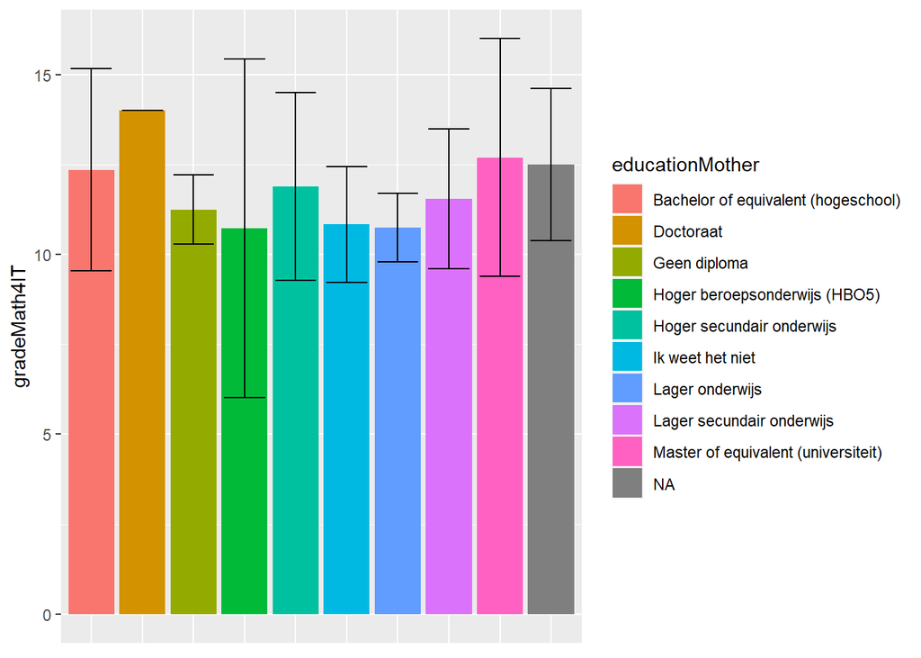

```r
educationMother <- dataset$EducationMother
gradeMath4IT <- dataset$GradeMath4IT

ggplot(data = dataset, mapping = aes(x = educationMother, y = gradeMath4IT,fill = educationMother)) +
  geom_bar(stat = "summary", fun.y = "mean", )  +
  geom_errorbar(stat = "summary", fun.data = "mean_sdl", fun.args = list(mult=1),width = .8)+
    theme(axis.title.x=element_blank(),
        axis.text.x=element_blank(),
        axis.ticks.x=element_blank())
```

## Onderzoek

```r
s1 <- dataset$GradeMath4IT[dataset$EducationMother == "Master of equivalent (universiteit)"]
s2 <- dataset$GradeMath4IT[dataset$EducationMother == "Lager secundair onderwijs"]

(t <- t.test(s1,s2))
```

```
##
##  Welch Two Sample t-test
##
## data:  s1 and s2
## t = 1.3161, df = 22.204, p-value = 0.2016
## alternative hypothesis: true difference in means is not equal to 0
## 95 percent confidence interval:
##  -0.6561803  2.9390086
## sample estimates:
## mean of x mean of y
##  12.69697  11.55556
```

```r
# Pooled standard deviation for two samples x and y
pooled_sd <- function(x, y) {
  sd_x <- sd(x, na.rm = TRUE)
  sd_y <- sd(y, na.rm = TRUE)
  n_x <- length(x)
  n_y <- length(y)

  sqrt( ((n_x - 1) * sd_x^2 + (n_y - 1) * sd_y^2)
        / (n_x + n_y - 2))
}

# Effect size, Cohen's d
cohens_d <- function(x, y) {
  (mean(y, na.rm = TRUE) - mean(x, na.rm = TRUE)) / pooled_sd(x, y)
}



cohend <- cohens_d(s1,s2)
```

## Conclusie

De p-waarde is: 0.202  
De cohens-d is: -0.375

# GradeMath4IT - OccupationFather

Op onderstaande grafiek is te zien hoe kinderen scoren op Math4IT opgedeeld per functie van de vader

```
## No summary function supplied, defaulting to `mean_se()`
```

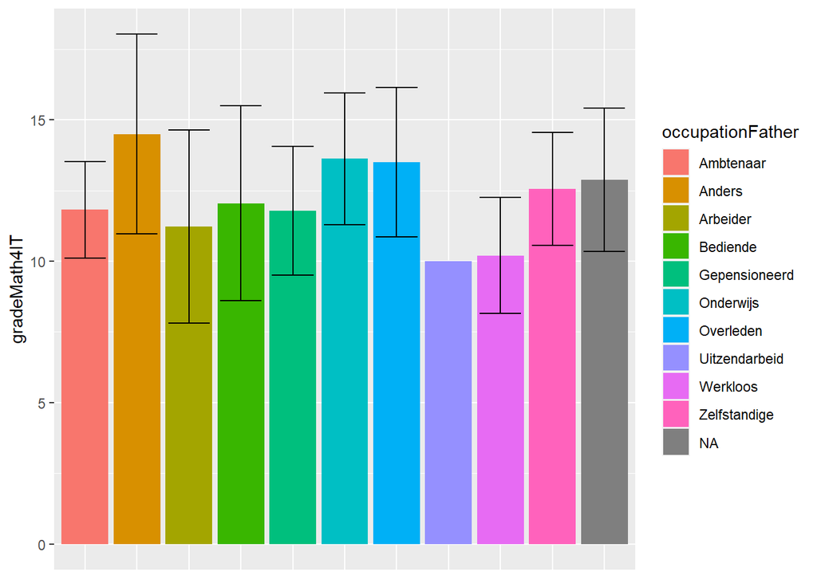

```r
occupationFather <- dataset$OccupationFather
gradeMath4IT <- dataset$GradeMath4IT

ggplot(data = dataset, mapping = aes(x = occupationFather, y = gradeMath4IT,fill = occupationFather)) +
  geom_bar(stat = "summary", fun.y = "mean", )  +
  geom_errorbar(stat = "summary", fun.data = "mean_sdl", fun.args = list(mult=1),width = .8)+
    theme(axis.title.x=element_blank(),
        axis.text.x=element_blank(),
        axis.ticks.x=element_blank())
```

## Onderzoek

```r
s1 <- dataset$GradeMath4IT[dataset$OccupationFather == "Ambtenaar"]
s2 <- dataset$GradeMath4IT[dataset$OccupationFather == "Werkloos"]

(t <- t.test(s1,s2))
```

```
##
##  Welch Two Sample t-test
##
## data:  s1 and s2
## t = 1.6408, df = 5.3375, p-value = 0.1581
## alternative hypothesis: true difference in means is not equal to 0
## 95 percent confidence interval:
##  -0.8695107  4.1058743
## sample estimates:
## mean of x mean of y
##  11.81818  10.20000
```

```r
# Pooled standard deviation for two samples x and y
pooled_sd <- function(x, y) {
  sd_x <- sd(x, na.rm = TRUE)
  sd_y <- sd(y, na.rm = TRUE)
  n_x <- length(x)
  n_y <- length(y)

  sqrt( ((n_x - 1) * sd_x^2 + (n_y - 1) * sd_y^2)
        / (n_x + n_y - 2))
}

# Effect size, Cohen's d
cohens_d <- function(x, y) {
  (mean(y, na.rm = TRUE) - mean(x, na.rm = TRUE)) / pooled_sd(x, y)
}



cohend <- cohens_d(s1,s2)
```

## Conclusie

De p-waarde is: 0.158  
De cohens-d is: -0.893

Hieruit kunnen we concluderen dat de functie van de vader een groot effect heeft.

$|d| \approx 0.80$  
$0.893 \approx 0.80$

# GradeMath4IT - OccupationMother

Op onderstaande grafiek is te zien hoe kinderen scoren op Math4IT opgedeeld per functie van de moeder

```
## No summary function supplied, defaulting to `mean_se()`
```

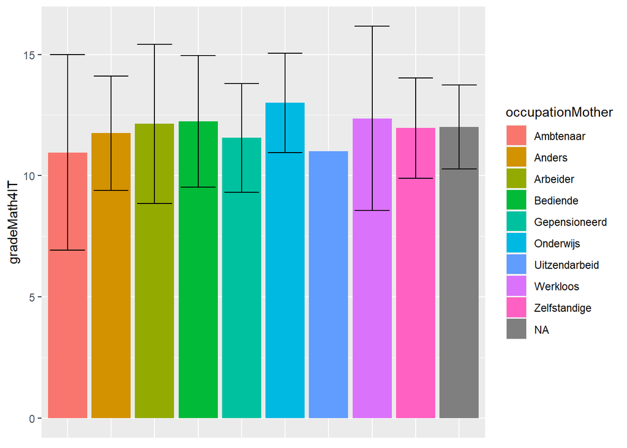

```r
occupationMother <- dataset$OccupationMother
gradeMath4IT <- dataset$GradeMath4IT

ggplot(data = dataset, mapping = aes(x = occupationMother, y = gradeMath4IT,fill = occupationMother)) +
  geom_bar(stat = "summary", fun.y = "mean", )  +
  geom_errorbar(stat = "summary", fun.data = "mean_sdl", fun.args = list(mult=1),width = .8)+
    theme(axis.title.x=element_blank(),
        axis.text.x=element_blank(),
        axis.ticks.x=element_blank())
```

## Onderzoek

```r
s1 <- dataset$GradeMath4IT[dataset$OccupationMother == "Ambtenaar"]
s2 <- dataset$GradeMath4IT[dataset$OccupationMother == "Werkloos"]

(t <- t.test(s1,s2))
```

```
##
##  Welch Two Sample t-test
##
## data:  s1 and s2
## t = -0.98366, df = 21.202, p-value = 0.3364
## alternative hypothesis: true difference in means is not equal to 0
## 95 percent confidence interval:
##  -4.386403  1.568221
## sample estimates:
## mean of x mean of y
##  10.95455  12.36364
```

```r
# Pooled standard deviation for two samples x and y
pooled_sd <- function(x, y) {
  sd_x <- sd(x, na.rm = TRUE)
  sd_y <- sd(y, na.rm = TRUE)
  n_x <- length(x)
  n_y <- length(y)

  sqrt( ((n_x - 1) * sd_x^2 + (n_y - 1) * sd_y^2)
        / (n_x + n_y - 2))
}

# Effect size, Cohen's d
cohens_d <- function(x, y) {
  (mean(y, na.rm = TRUE) - mean(x, na.rm = TRUE)) / pooled_sd(x, y)
}



cohend <- cohens_d(s1,s2)
```

## Conclusie

De p-waarde is: 0.336  
De cohens-d is: 0.357

$|d| \approx 0.20$  
$0.357 \approx 0.20$

Er is geen verband tussen de 2 variabelen.

# GradeMath4IT - FamilyIncome

```
## No summary function supplied, defaulting to `mean_se()`
```

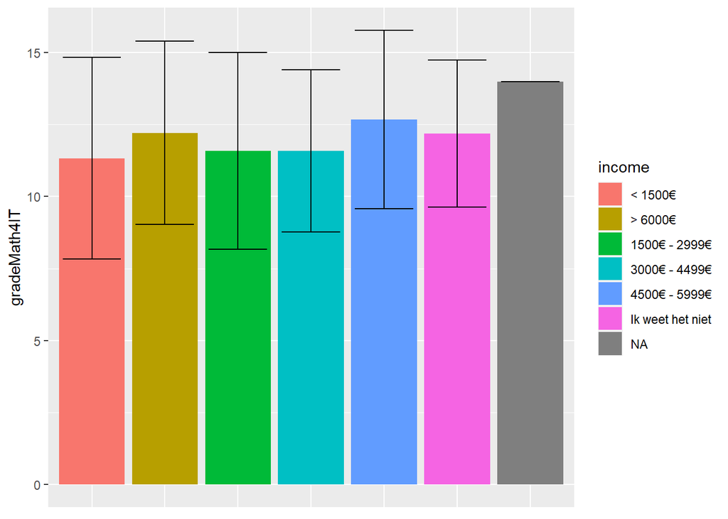

```r
income <- dataset$FamilyIncome
gradeMath4IT <- dataset$GradeMath4IT

ggplot(data = dataset, mapping = aes(x = income, y = gradeMath4IT,fill = income)) +
  geom_bar(stat = "summary", fun.y = "mean", )  +
  geom_errorbar(stat = "summary", fun.data = "mean_sdl", fun.args = list(mult=1),width = .8)+
    theme(axis.title.x=element_blank(),
        axis.text.x=element_blank(),
        axis.ticks.x=element_blank())
```

## Onderzoek

```r
s1 <- dataset$GradeMath4IT[dataset$FamilyIncome == "> 6000€"]
s2 <- dataset$GradeMath4IT[dataset$FamilyIncome == "< 1500€"]

(t <- t.test(s1,s2))
```

```
##
##  Welch Two Sample t-test
##
## data:  s1 and s2
## t = 0.4005, df = 2.7569, p-value = 0.7178
## alternative hypothesis: true difference in means is not equal to 0
## 95 percent confidence interval:
##  -6.481739  8.243644
## sample estimates:
## mean of x mean of y
##  12.21429  11.33333
```

```r
# Pooled standard deviation for two samples x and y
pooled_sd <- function(x, y) {
  sd_x <- sd(x, na.rm = TRUE)
  sd_y <- sd(y, na.rm = TRUE)
  n_x <- length(x)
  n_y <- length(y)

  sqrt( ((n_x - 1) * sd_x^2 + (n_y - 1) * sd_y^2)
        / (n_x + n_y - 2))
}

# Effect size, Cohen's d
cohens_d <- function(x, y) {
  (mean(y, na.rm = TRUE) - mean(x, na.rm = TRUE)) / pooled_sd(x, y)
}



cohend <- cohens_d(s1,s2)
```

## Conclusie

De p-waarde is: 0.718  
De cohens-d is: -0.268

Hieruit kunnen we concluderen dat het familieinkomen een klein effect heeft.

$|d| \approx 0.20$  
$0.268 \approx 0.20$

Er is geen verband tussen de 2 variabelen.

# GradePOD1 - EducationFather

Op onderstaande grafiek is te zien hoe kinderen scoren op POD 1 opgedeeld per educatie niveau van de vader

```
## No summary function supplied, defaulting to `mean_se()`
```

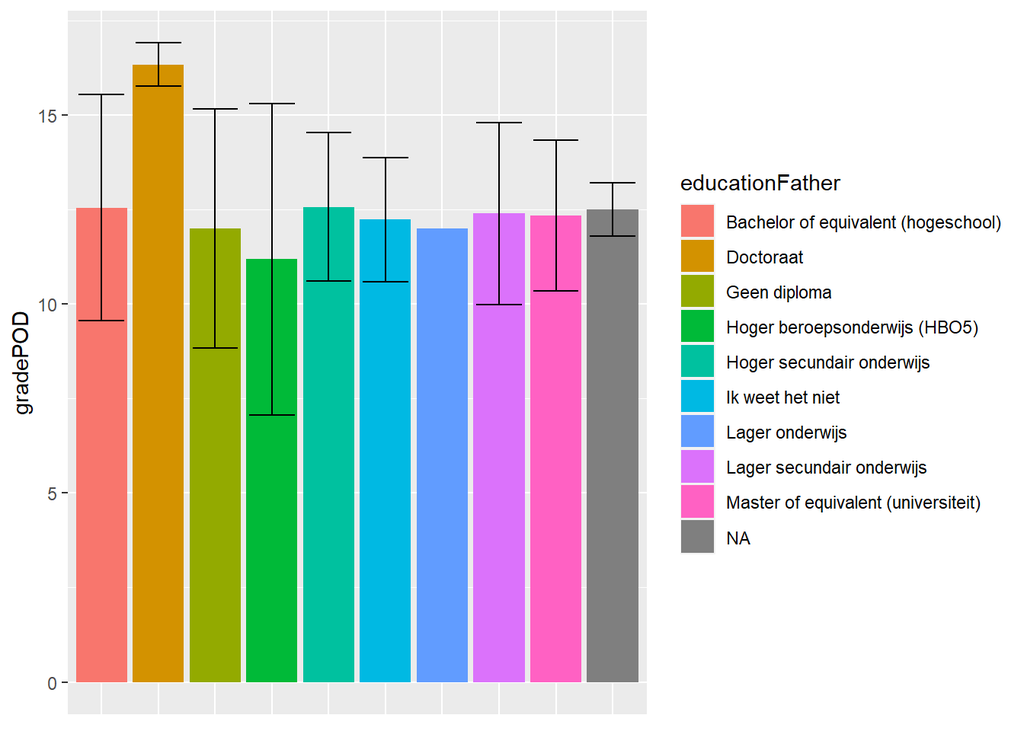

```r
educationFather <- dataset$EducationFather
gradePOD <- dataset$GradePOD1

ggplot(data = dataset, mapping = aes(x = educationFather, y = gradePOD,fill = educationFather)) +
  geom_bar(stat = "summary", fun.y = "mean", )  +
  geom_errorbar(stat = "summary", fun.data = "mean_sdl", fun.args = list(mult=1),width = .8)+
    theme(axis.title.x=element_blank(),
        axis.text.x=element_blank(),
        axis.ticks.x=element_blank())
```

## Onderzoek

```r
s1 <- dataset$GradePOD1[dataset$EducationFather == "Master of equivalent (universiteit)"]
s2 <- dataset$GradePOD1[dataset$EducationFather == "Lager secundair onderwijs"]

(t <- t.test(s1,s2))
```

```
##
##  Welch Two Sample t-test
##
## data:  s1 and s2
## t = -0.098442, df = 38.738, p-value = 0.9221
## alternative hypothesis: true difference in means is not equal to 0
## 95 percent confidence interval:
##  -1.249359  1.133417
## sample estimates:
## mean of x mean of y
##  12.33333  12.39130
```

```r
# Pooled standard deviation for two samples x and y
pooled_sd <- function(x, y) {
  sd_x <- sd(x, na.rm = TRUE)
  sd_y <- sd(y, na.rm = TRUE)
  n_x <- length(x)
  n_y <- length(y)

  sqrt( ((n_x - 1) * sd_x^2 + (n_y - 1) * sd_y^2)
        / (n_x + n_y - 2))
}

# Effect size, Cohen's d
cohens_d <- function(x, y) {
  (mean(y, na.rm = TRUE) - mean(x, na.rm = TRUE)) / pooled_sd(x, y)
}



cohend <- cohens_d(s1,s2)
```

## Conclusie

De p-waarde is: 0.922  
De cohens-d is: 0.027

Hieruit kunnen we concluderen dat de opleiding van de vader zeer weinig effect heeft.

$|d| \approx 0.01$  
$0.027 \approx 0.01$

Er is geen verband tussen de 2 variabelen.

# GradePOD1 - EducationMother

```
## No summary function supplied, defaulting to `mean_se()`
```

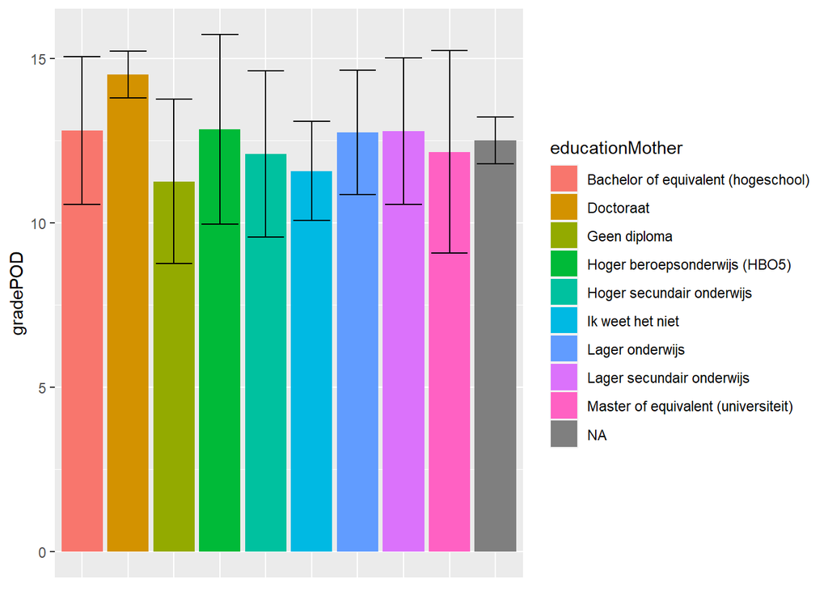

```r
educationMother <- dataset$EducationMother
gradePOD <- dataset$GradePOD1

ggplot(data = dataset, mapping = aes(x = educationMother, y = gradePOD,fill = educationMother)) +
  geom_bar(stat = "summary", fun.y = "mean", )  +
  geom_errorbar(stat = "summary", fun.data = "mean_sdl", fun.args = list(mult=1),width = .8)+
    theme(axis.title.x=element_blank(),
        axis.text.x=element_blank(),
        axis.ticks.x=element_blank())
```

## Onderzoek

```r
s1 <- dataset$GradePOD1[dataset$EducationMother == "Master of equivalent (universiteit)"]
s2 <- dataset$GradePOD1[dataset$EducationMother == "Lager secundair onderwijs"]

(t <- t.test(s1,s2))
```

```
##
##  Welch Two Sample t-test
##
## data:  s1 and s2
## t = -0.68433, df = 17.395, p-value = 0.5028
## alternative hypothesis: true difference in means is not equal to 0
## 95 percent confidence interval:
##  -2.553717  1.301192
## sample estimates:
## mean of x mean of y
##  12.15152  12.77778
```

```r
# Pooled standard deviation for two samples x and y
pooled_sd <- function(x, y) {
  sd_x <- sd(x, na.rm = TRUE)
  sd_y <- sd(y, na.rm = TRUE)
  n_x <- length(x)
  n_y <- length(y)

  sqrt( ((n_x - 1) * sd_x^2 + (n_y - 1) * sd_y^2)
        / (n_x + n_y - 2))
}

# Effect size, Cohen's d
cohens_d <- function(x, y) {
  (mean(y, na.rm = TRUE) - mean(x, na.rm = TRUE)) / pooled_sd(x, y)
}



cohend <- cohens_d(s1,s2)
```

## Conclusie

De p-waarde is: 0.503  
De cohens-d is: 0.216

Hieruit kunnen we concluderen dat de opleiding van de moeder een klein effect heeft.

$|d| \approx 0.20$  
$0.216 \approx 0.20$

Er is geen verband tussen de 2 variabelen.

# GradePOD1 - OccupationFather

```
## No summary function supplied, defaulting to `mean_se()`
```

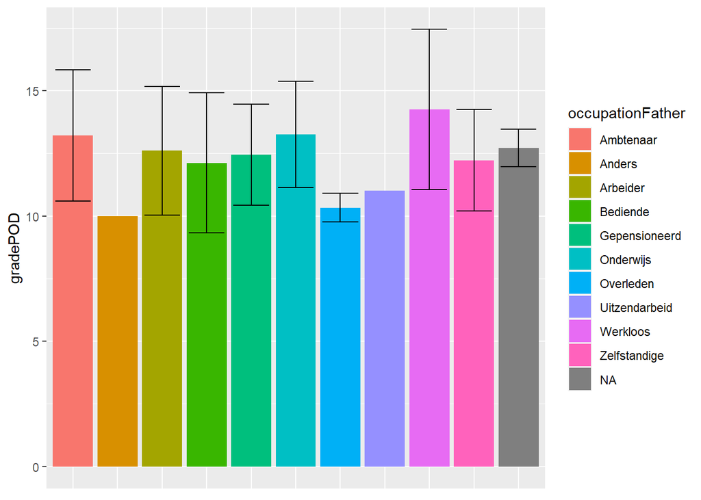

```r
occupationFather <- dataset$OccupationFather
gradePOD <- dataset$GradePOD1

ggplot(data = dataset, mapping = aes(x = occupationFather, y = gradePOD,fill = occupationFather)) +
  geom_bar(stat = "summary", fun.y = "mean", )  +
  geom_errorbar(stat = "summary", fun.data = "mean_sdl", fun.args = list(mult=1),width = .8)+
    theme(axis.title.x=element_blank(),
        axis.text.x=element_blank(),
        axis.ticks.x=element_blank())
```

## Onderzoek

```r
s1 <- dataset$GradePOD1[dataset$OccupationFather == "Ambtenaar"]
s2 <- dataset$GradePOD1[dataset$OccupationFather == "Werkloos"]

(t <- t.test(s1,s2))
```

```
##
##  Welch Two Sample t-test
##
## data:  s1 and s2
## t = -0.61718, df = 3.7014, p-value = 0.573
## alternative hypothesis: true difference in means is not equal to 0
## 95 percent confidence interval:
##  -5.880654  3.797321
## sample estimates:
## mean of x mean of y
##  13.20833  14.25000
```

```r
# Pooled standard deviation for two samples x and y
pooled_sd <- function(x, y) {
  sd_x <- sd(x, na.rm = TRUE)
  sd_y <- sd(y, na.rm = TRUE)
  n_x <- length(x)
  n_y <- length(y)

  sqrt( ((n_x - 1) * sd_x^2 + (n_y - 1) * sd_y^2)
        / (n_x + n_y - 2))
}

# Effect size, Cohen's d
cohens_d <- function(x, y) {
  (mean(y, na.rm = TRUE) - mean(x, na.rm = TRUE)) / pooled_sd(x, y)
}



cohend <- cohens_d(s1,s2)
```

## Conclusie

De p-waarde is: 0.573  
De cohens-d is: 0.372

# GradePOD1 - OccupationMother

```
## No summary function supplied, defaulting to `mean_se()`
```

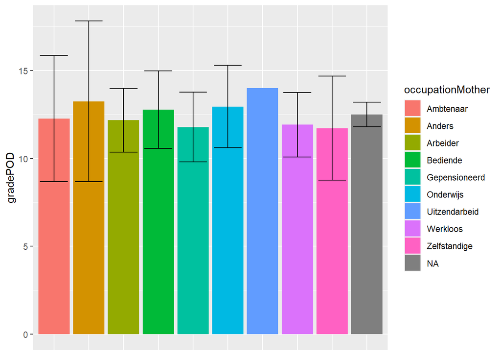

```r
occupationMother <- dataset$OccupationMother
gradePOD <- dataset$GradePOD1

ggplot(data = dataset, mapping = aes(x = occupationMother, y = gradePOD,fill = occupationMother)) +
  geom_bar(stat = "summary", fun.y = "mean", )  +
  geom_errorbar(stat = "summary", fun.data = "mean_sdl", fun.args = list(mult=1),width = .8)+
    theme(axis.title.x=element_blank(),
        axis.text.x=element_blank(),
        axis.ticks.x=element_blank())
```

## Onderzoek

```r
s1 <- dataset$GradePOD1[dataset$OccupationMother == "Ambtenaar"]
s2 <- dataset$GradePOD1[dataset$OccupationMother == "Werkloos"]

(t <- t.test(s1,s2))
```

```
##
##  Welch Two Sample t-test
##
## data:  s1 and s2
## t = 0.37604, df = 33, p-value = 0.7093
## alternative hypothesis: true difference in means is not equal to 0
## 95 percent confidence interval:
##  -1.518066  2.206472
## sample estimates:
## mean of x mean of y
##  12.26087  11.91667
```

```r
# Pooled standard deviation for two samples x and y
pooled_sd <- function(x, y) {
  sd_x <- sd(x, na.rm = TRUE)
  sd_y <- sd(y, na.rm = TRUE)
  n_x <- length(x)
  n_y <- length(y)

  sqrt( ((n_x - 1) * sd_x^2 + (n_y - 1) * sd_y^2)
        / (n_x + n_y - 2))
}

# Effect size, Cohen's d
cohens_d <- function(x, y) {
  (mean(y, na.rm = TRUE) - mean(x, na.rm = TRUE)) / pooled_sd(x, y)
}



cohend <- cohens_d(s1,s2)
```

## Conclusie

De p-waarde is: 0.709  
De cohens-d is: -0.112

$|d| \approx 0.20$  
$0.112 \approx 0.20$

Er is geen verband tussen de 2 variabelen.

# GradePOD1 - Familyincome

```
## No summary function supplied, defaulting to `mean_se()`
```

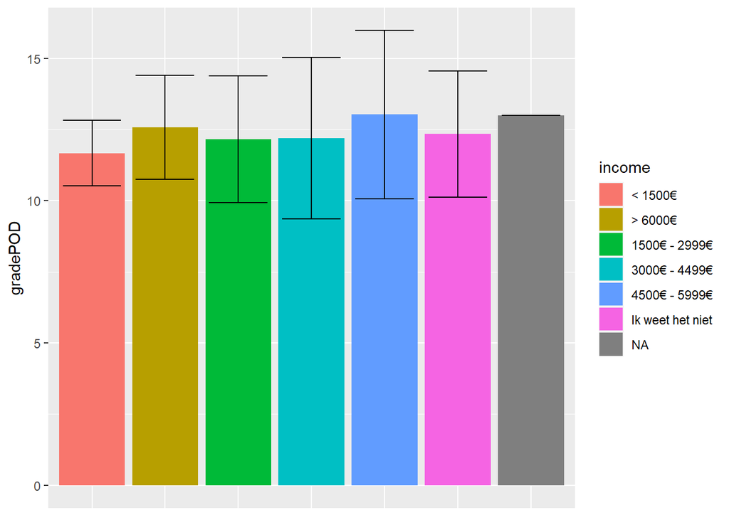

```r
income <- dataset$FamilyIncome
gradePOD <- dataset$GradePOD1

ggplot(data = dataset, mapping = aes(x = income, y = gradePOD,fill = income)) +
  geom_bar(stat = "summary", fun.y = "mean", )  +
  geom_errorbar(stat = "summary", fun.data = "mean_sdl", fun.args = list(mult=1),width = .8)+
    theme(axis.title.x=element_blank(),
        axis.text.x=element_blank(),
        axis.ticks.x=element_blank())
```

## Onderzoek

```r
s1 <- dataset$GradePOD1[dataset$FamilyIncome == "> 6000€"]
s2 <- dataset$GradePOD1[dataset$FamilyIncome == "< 1500€"]



(t <- t.test(s1,s2))
```

```
##
##  Welch Two Sample t-test
##
## data:  s1 and s2
## t = 1.0947, df = 4.5235, p-value = 0.3285
## alternative hypothesis: true difference in means is not equal to 0
## 95 percent confidence interval:
##  -1.288878  3.098401
## sample estimates:
## mean of x mean of y
##  12.57143  11.66667
```

```r
# Pooled standard deviation for two samples x and y
pooled_sd <- function(x, y) {
  sd_x <- sd(x, na.rm = TRUE)
  sd_y <- sd(y, na.rm = TRUE)
  n_x <- length(x)
  n_y <- length(y)

  sqrt( ((n_x - 1) * sd_x^2 + (n_y - 1) * sd_y^2)
        / (n_x + n_y - 2))
}

# Effect size, Cohen's d
cohens_d <- function(x, y) {
  (mean(y, na.rm = TRUE) - mean(x, na.rm = TRUE)) / pooled_sd(x, y)
}



cohend <- cohens_d(s1,s2)
```

## Conclusie

De p-waarde is: 0.328  
De cohens-d is: -0.546

Hieruit kunnen we concluderen dat het familieinkomen een middelmatig effect heeft.

$|d| \approx 0.50$  
$0.546 \approx 0.50$